# Homework4Econ488

Michael Vargas

May 1, 2019

```r
# 1 A)

setwd("C:\\Users\\micha\\Desktop\\ECON 488 CAUSAL INFERENCE\\Homework4")
dataPSID <- read.csv("nswpsid.csv")

# Add new columns to data set
dataPSID$re74sq <- I(dataPSID$re74^2)
dataPSID$re75sq <- I(dataPSID$re75^2)
dataPSID$agesq <- I(dataPSID$age^2)
dataPSID$edusq <- I(dataPSID$edu^2)
dataPSID$u74black <- dataPSID$u74 * dataPSID$black

# Predict p-scores using LPM and Logit specifications
model_LPM <- lm(dataPSID$treat ~ dataPSID$age + dataPSID$agesq + dataPSID$edu + dataPSID$edusq
                + dataPSID$married + dataPSID$nodegree + dataPSID$black + dataPSID$hisp
                + dataPSID$re74 + dataPSID$re75 + dataPSID$re74sq + dataPSID$re75sq + u74black,
                data = dataPSID)
model_Logit <- glm(dataPSID$treat ~ dataPSID$age + dataPSID$agesq + dataPSID$edu + dataPSID$edusq
                + dataPSID$married + dataPSID$nodegree + dataPSID$black + dataPSID$hisp
                + dataPSID$re74 + dataPSID$re75 + dataPSID$re74sq + dataPSID$re75sq + u74black,
                family = binomial(link="logit"),
                data = dataPSID)

pscore_LPM <- predict(model_LPM, data = dataPSID, type = "response")
pscore_Logit <- predict(model_Logit, data = dataPSID, type = "response")

dataPSID$lpm_p <- pscore_LPM
dataPSID$logit_p <- pscore_Logit
```

2. It looks like there are two distinct clusters of pscores for the LPM specification when plotted against the Logit specification. There is also intense clustering in the lower left corner for the “bottom” group, and light clustering in the top right for the “top” group. This implies that the logit pscores have a smooth distribution, while the LPM pscores cluster into two distinct groups.

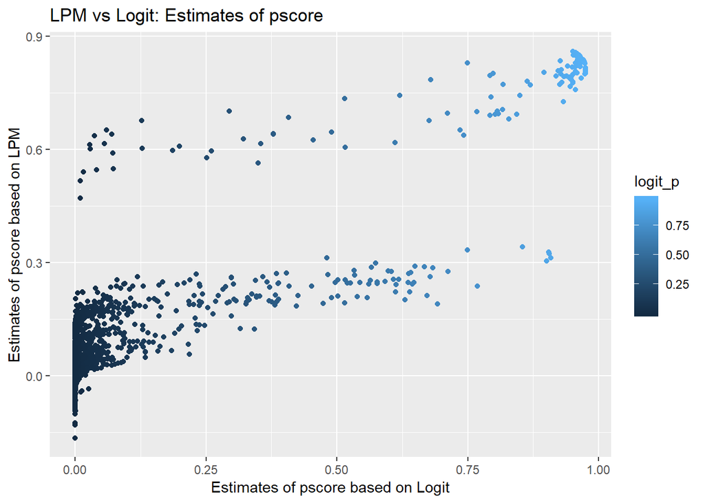

```r
# Plot p-scores
pscoreGraph <- ggplot(dataPSID, aes(x = logit_p, y = lpm_p, color = logit_p)) +
               geom_point() + ylab("Estimates of pscore based on LPM") +
               xlab("Estimates of pscore based on Logit") +
               ggtitle("LPM vs Logit: Estimates of pscore")
pscoreGraph
```

2) We will be matching on pscores, thus we need the range of pscores to be the same for the treated and control groups. This allows us to match units in the treated group with units in the control group that have the same pscore. 1350 total units were dropped, 1344 from the control group, 6 from the treated group. I am not surprised because I expected a lot of pscores to be quite low for the control group, by virtue of the fact those units would have a low probability of being assigned treatment given their predetermined characteristics if they are in fact in the control group.

```r
# Find max and min of common support
treatedMax <- max(dataPSID$logit_p[dataPSID$treat == 1])
treatedMin <- min(dataPSID$logit_p[dataPSID$treat == 1])
controlMax <- max(dataPSID$logit_p[dataPSID$treat == 0])
controlMin <- min(dataPSID$logit_p[dataPSID$treat == 0])
commonSupportMax <- min(treatedMax, controlMax)
commonSupportMin <- max(treatedMin, controlMin)

# Drop all units outside common support & count number of dropped
dataPSID$toDrop <- dataPSID$logit_p
dataPSID$toDrop <- ifelse(dataPSID$toDrop > commonSupportMax | dataPSID$toDrop < commonSupportMin, 1, 0)
numberOfTreatedDropped <- sum(dataPSID$treat == 1 & dataPSID$toDrop == 1)
numberOfControlDropped <- sum(dataPSID$treat == 0 & dataPSID$toDrop == 1)
dataPSID_Match <- subset(dataPSID, dataPSID$toDrop != 1)
```

3. We cannot eyeball estimates in each graph, or across graphs. There is a cluster of low pscores in the control graph and a cluster of high pscores in the treatment graph that drag up the regression or drag down the regression, respectively. This means we can not accurately eyeball the difference in heights of the two graphs, or even the difference in starting height and ending height within each graph.

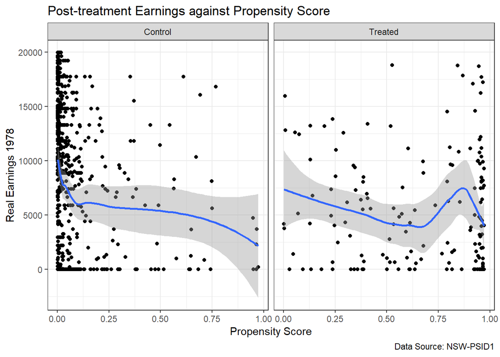

```r
# A)

plot_data <- subset(dataPSID_Match, dataPSID_Match$re78 < 20000)
plot_data$treat <- factor(ifelse(plot_data$treat == 1, "Treated", "Control"))

replica <- ggplot(plot_data, aes(x = plot_data$logit_p, y = plot_data$re78)) +
           facet_grid(~plot_data$treat) + geom_point() + geom_smooth(method = "loess", span = 0.5) +
           ylab("Real Earnings 1978") + xlab("Propensity Score") +
           ggtitle("Post-treatment Earnings against Propensity Score") +
           labs(caption = "Data Source: NSW-PSID1") + theme_bw()
replica
```

4 A) The distribution of pscores amongst the treated and control groups are skewed to the left and right, respectively. The 9th strata for the control group is unoccupied.

```r
# Split data into stratas
dataPSID_Match$strata <- .bincode(dataPSID_Match$logit_p, breaks = seq(0, 1, 0.1))
table(dataPSID_Match[dataPSID_Match$treat == 1,]$strata)
```

```
##
##  1  2  3  4  5  6  7  8  9 10
## 11  7 11 16  5 15 14  8 13 79
```

```r
table(dataPSID_Match[dataPSID_Match$treat == 0,]$strata)
```

```
##
##    1    2    3    4    5    6    7    8   10
## 1018   53   24   17    8    6    8    5    7
```

2. Yes. We will be matching units on pscores within each strata in order to eventually estimate the ATE, thus it is critical to test for covariate balance between the control and test groups within each strata. This step is needed to identify potential confounding variable influence within each strata (a.k.a, any systematic differences in predetermined characteristics amongst the treated and control groups within each strata).

```r
# Create data sets for each strata
strata1 <- subset(dataPSID_Match, dataPSID_Match$strata == 1)
strata2 <- subset(dataPSID_Match, dataPSID_Match$strata == 2)
strata3 <- subset(dataPSID_Match, dataPSID_Match$strata == 3)
strata4 <- subset(dataPSID_Match, dataPSID_Match$strata == 4)
strata5 <- subset(dataPSID_Match, dataPSID_Match$strata == 5)
strata6 <- subset(dataPSID_Match, dataPSID_Match$strata == 6)
strata7 <- subset(dataPSID_Match, dataPSID_Match$strata == 7)
strata8 <- subset(dataPSID_Match, dataPSID_Match$strata == 8)
strata10 <- subset(dataPSID_Match, dataPSID_Match$strata == 10)
```

```r
# Test for covariate balance within each populated strata (excluding strata 9)

# Strata 1
eq1 <- dataPSID_Match$age ~ dataPSID_Match$treat
eq2 <- dataPSID_Match$edu ~ dataPSID_Match$treat
eq3 <- dataPSID_Match$married  ~ dataPSID_Match$treat
eq4 <- dataPSID_Match$nodegree  ~ dataPSID_Match$treat
eq5 <- dataPSID_Match$black  ~ dataPSID_Match$treat
eq6 <- dataPSID_Match$hisp  ~ dataPSID_Match$treat
eq7 <- dataPSID_Match$re74  ~ dataPSID_Match$treat
eq8 <- dataPSID_Match$re75  ~ dataPSID_Match$treat

system1Alt <- list(eq1 = eq1, eq2 = eq2, eq3 = eq3, eq4 = eq4, eq5 = eq5,
               eq6 = eq6, eq7 = eq7, eq8 = eq8)
sur_fit1 <- systemfit::systemfit(system1Alt, method = "SUR", data = strata1)
summary(sur_fit1)$coefficients[,c("Estimate", "Std. Error", "Pr(>|t|)")]
```

```
##                               Estimate   Std. Error     Pr(>|t|)
## eq1_(Intercept)           3.096161e+01 2.716300e-01 0.000000e+00
## eq1_dataPSID_Match$treat -5.196242e+00 7.390250e-01 3.272049e-12
## eq2_(Intercept)           1.114136e+01 7.447101e-02 0.000000e+00
## eq2_dataPSID_Match$treat -7.279534e-01 2.026136e-01 3.391227e-04
## eq3_(Intercept)           7.757417e-01 1.225010e-02 0.000000e+00
## eq3_dataPSID_Match$treat -5.802110e-01 3.332890e-02 0.000000e+00
## eq4_(Intercept)           4.118674e-01 1.442100e-02 0.000000e+00
## eq4_dataPSID_Match$treat  2.864567e-01 3.923528e-02 4.913847e-13
## eq5_(Intercept)           4.040140e-01 1.407228e-02 0.000000e+00
## eq5_dataPSID_Match$treat  4.339749e-01 3.828651e-02 0.000000e+00
## eq6_(Intercept)           5.148342e-02 6.612114e-03 1.376677e-14
## eq6_dataPSID_Match$treat  9.969093e-03 1.798961e-02 5.795641e-01
## eq7_(Intercept)           1.138648e+04 2.618622e+02 0.000000e+00
## eq7_dataPSID_Match$treat -9.220666e+03 7.124498e+02 0.000000e+00
## eq8_(Intercept)           9.528639e+03 2.287125e+02 0.000000e+00
## eq8_dataPSID_Match$treat -7.945229e+03 6.222592e+02 0.000000e+00
```

```r
eq1 <- dataPSID_Match$age ~ 1
eq2 <- dataPSID_Match$edu ~ 1
eq3 <- dataPSID_Match$married ~ 1
eq4 <- dataPSID_Match$nodegree  ~ 1
eq5 <- dataPSID_Match$black ~ 1
eq6 <- dataPSID_Match$hisp ~ 1
eq7 <- dataPSID_Match$re74  ~ 1
eq8 <- dataPSID_Match$re75 ~ 1

system1Null <- list(eq1 = eq1, eq2 = eq2, eq3 = eq3, eq4 = eq4, eq5 = eq5,
               eq6 = eq6, eq7 = eq7, eq8 = eq8)
null_fit1 <- systemfit::systemfit(system1Null, method = "SUR", data=strata1)
lmtest::lrtest(null_fit1,sur_fit1)
```

```
## Likelihood ratio test
##
## Model 1: null_fit1
## Model 2: sur_fit1
##   #Df LogLik Df  Chisq Pr(>Chisq)
## 1  44 -37104
## 2  52 -36810  8 587.43  < 2.2e-16 ***
## ---
## Signif. codes:  0 '***' 0.001 '**' 0.01 '*' 0.05 '.' 0.1 ' ' 1
```

```r
# Strata 2
eq1 <- dataPSID_Match$age ~ dataPSID_Match$treat
eq2 <- dataPSID_Match$edu ~ dataPSID_Match$treat
eq3 <- dataPSID_Match$married  ~ dataPSID_Match$treat
eq4 <- dataPSID_Match$nodegree  ~ dataPSID_Match$treat
eq5 <- dataPSID_Match$black  ~ dataPSID_Match$treat
eq6 <- dataPSID_Match$hisp  ~ dataPSID_Match$treat
eq7 <- dataPSID_Match$re74  ~ dataPSID_Match$treat
eq8 <- dataPSID_Match$re75  ~ dataPSID_Match$treat

system2Alt <- list(eq1 = eq1, eq2 = eq2, eq3 = eq3, eq4 = eq4, eq5 = eq5,
               eq6 = eq6, eq7 = eq7, eq8 = eq8)
sur_fit2 <- systemfit::systemfit(system2Alt, method = "SUR", data = strata2)
summary(sur_fit2)$coefficients[,c("Estimate", "Std. Error", "Pr(>|t|)")]
```

```
##                               Estimate   Std. Error     Pr(>|t|)
## eq1_(Intercept)           3.096161e+01 2.716300e-01 0.000000e+00
## eq1_dataPSID_Match$treat -5.196242e+00 7.390250e-01 3.272049e-12
## eq2_(Intercept)           1.114136e+01 7.447101e-02 0.000000e+00
## eq2_dataPSID_Match$treat -7.279534e-01 2.026136e-01 3.391227e-04
## eq3_(Intercept)           7.757417e-01 1.225010e-02 0.000000e+00
## eq3_dataPSID_Match$treat -5.802110e-01 3.332890e-02 0.000000e+00
## eq4_(Intercept)           4.118674e-01 1.442100e-02 0.000000e+00
## eq4_dataPSID_Match$treat  2.864567e-01 3.923528e-02 4.913847e-13
## eq5_(Intercept)           4.040140e-01 1.407228e-02 0.000000e+00
## eq5_dataPSID_Match$treat  4.339749e-01 3.828651e-02 0.000000e+00
## eq6_(Intercept)           5.148342e-02 6.612114e-03 1.376677e-14
## eq6_dataPSID_Match$treat  9.969093e-03 1.798961e-02 5.795641e-01
## eq7_(Intercept)           1.138648e+04 2.618622e+02 0.000000e+00
## eq7_dataPSID_Match$treat -9.220666e+03 7.124498e+02 0.000000e+00
## eq8_(Intercept)           9.528639e+03 2.287125e+02 0.000000e+00
## eq8_dataPSID_Match$treat -7.945229e+03 6.222592e+02 0.000000e+00
```

```r
eq1 <- dataPSID_Match$age ~ 1
eq2 <- dataPSID_Match$edu ~ 1
eq3 <- dataPSID_Match$married ~ 1
eq4 <- dataPSID_Match$nodegree  ~ 1
eq5 <- dataPSID_Match$black ~ 1
eq6 <- dataPSID_Match$hisp ~ 1
eq7 <- dataPSID_Match$re74  ~ 1
eq8 <- dataPSID_Match$re75 ~ 1

system2Null <- list(eq1 = eq1, eq2 = eq2, eq3 = eq3, eq4 = eq4, eq5 = eq5,
               eq6 = eq6, eq7 = eq7, eq8 = eq8)
null_fit2 <- systemfit::systemfit(system2Null, method = "SUR", data=strata2)
lmtest::lrtest(null_fit2,sur_fit2)
```

```
## Likelihood ratio test
##
## Model 1: null_fit2
## Model 2: sur_fit2
##   #Df LogLik Df  Chisq Pr(>Chisq)
## 1  44 -37104
## 2  52 -36810  8 587.43  < 2.2e-16 ***
## ---
## Signif. codes:  0 '***' 0.001 '**' 0.01 '*' 0.05 '.' 0.1 ' ' 1
```

```r
eq1 <- dataPSID_Match$age ~ dataPSID_Match$treat
eq2 <- dataPSID_Match$edu ~ dataPSID_Match$treat
eq3 <- dataPSID_Match$married  ~ dataPSID_Match$treat
eq4 <- dataPSID_Match$nodegree  ~ dataPSID_Match$treat
eq5 <- dataPSID_Match$black  ~ dataPSID_Match$treat
eq6 <- dataPSID_Match$hisp  ~ dataPSID_Match$treat
eq7 <- dataPSID_Match$re74  ~ dataPSID_Match$treat
eq8 <- dataPSID_Match$re75  ~ dataPSID_Match$treat

system3Alt <- list(eq1 = eq1, eq2 = eq2, eq3 = eq3, eq4 = eq4, eq5 = eq5,
               eq6 = eq6, eq7 = eq7, eq8 = eq8)
sur_fit3 <- systemfit::systemfit(system3Alt, method = "SUR", data = strata3)
summary(sur_fit3)$coefficients[,c("Estimate", "Std. Error", "Pr(>|t|)")]
```

```
##                               Estimate   Std. Error     Pr(>|t|)
## eq1_(Intercept)           3.096161e+01 2.716300e-01 0.000000e+00
## eq1_dataPSID_Match$treat -5.196242e+00 7.390250e-01 3.272049e-12
## eq2_(Intercept)           1.114136e+01 7.447101e-02 0.000000e+00
## eq2_dataPSID_Match$treat -7.279534e-01 2.026136e-01 3.391227e-04
## eq3_(Intercept)           7.757417e-01 1.225010e-02 0.000000e+00
## eq3_dataPSID_Match$treat -5.802110e-01 3.332890e-02 0.000000e+00
## eq4_(Intercept)           4.118674e-01 1.442100e-02 0.000000e+00
## eq4_dataPSID_Match$treat  2.864567e-01 3.923528e-02 4.913847e-13
## eq5_(Intercept)           4.040140e-01 1.407228e-02 0.000000e+00
## eq5_dataPSID_Match$treat  4.339749e-01 3.828651e-02 0.000000e+00
## eq6_(Intercept)           5.148342e-02 6.612114e-03 1.376677e-14
## eq6_dataPSID_Match$treat  9.969093e-03 1.798961e-02 5.795641e-01
## eq7_(Intercept)           1.138648e+04 2.618622e+02 0.000000e+00
## eq7_dataPSID_Match$treat -9.220666e+03 7.124498e+02 0.000000e+00
## eq8_(Intercept)           9.528639e+03 2.287125e+02 0.000000e+00
## eq8_dataPSID_Match$treat -7.945229e+03 6.222592e+02 0.000000e+00
```

```r
eq1 <- dataPSID_Match$age ~ 1
eq2 <- dataPSID_Match$edu ~ 1
eq3 <- dataPSID_Match$married ~ 1
eq4 <- dataPSID_Match$nodegree  ~ 1
eq5 <- dataPSID_Match$black ~ 1
eq6 <- dataPSID_Match$hisp ~ 1
eq7 <- dataPSID_Match$re74  ~ 1
eq8 <- dataPSID_Match$re75 ~ 1

system3Null <- list(eq1 = eq1, eq2 = eq2, eq3 = eq3, eq4 = eq4, eq5 = eq5,
               eq6 = eq6, eq7 = eq7, eq8 = eq8)
null_fit3 <- systemfit::systemfit(system3Null, method = "SUR", data=strata3)
lmtest::lrtest(null_fit3,sur_fit3)
```

```
## Likelihood ratio test
##
## Model 1: null_fit3
## Model 2: sur_fit3
##   #Df LogLik Df  Chisq Pr(>Chisq)
## 1  44 -37104
## 2  52 -36810  8 587.43  < 2.2e-16 ***
## ---
## Signif. codes:  0 '***' 0.001 '**' 0.01 '*' 0.05 '.' 0.1 ' ' 1
```